# Homework 09

The kernel-tuning question moved here from Homework 08. A solution for Question 1 will be available after Monday, October 26, 2026. No solution will be provided for Question 2.

## Question 1: Choosing an SVM kernel

Use `saheart.csv` from the combined ZIP. As in Homework 7, predict `chd` using the same nine predictors, coding `famhist` as 1 for `Absent` and 2 for `Present`.

Compare SVMs with a linear kernel, polynomial kernels of degrees 2 (quadratic), 3, and 4, and a radial basis kernel. Choose **no more than 20 candidate settings in total** across these kernels. Vary the cost $C$ for each kernel and the radial scale $\gamma$ for the radial kernel. State any other kernel settings you hold fixed.

Divide the observations into five folds yourself and use the same folds for all candidates. Standardize predictors using only the fitting observations in each fold. Report the candidate settings and their mean cross-validation misclassification rates. Which kernel and settings do you prefer? Give a brief justification.

### Answer

**Candidate settings.** I use 20 candidates, the stated maximum, spread across the five kernels:

Table 1: The 20 candidate settings.

| Kernel | Varied | Settings held fixed | Count |
| --- | --- | --- | --- |
| Linear | $C\in\{0.01,0.1,1,10\}$ | — | 4 |
| Polynomial, degree 2 | $C\in\{0.01,0.1,1\}$ | $\gamma=1/p=1/9$, $\text{coef}_0=1$ | 3 |
| Polynomial, degree 3 | $C\in\{0.01,0.1,1\}$ | $\gamma=1/p$, $\text{coef}_0=1$ | 3 |
| Polynomial, degree 4 | $C\in\{0.01,0.1,1\}$ | $\gamma=1/p$, $\text{coef}_0=1$ | 3 |
| Radial | $C\in\{0.1,1,10\}$, $\gamma\in\{0.05,0.2\}$, plus $C=100,\gamma=0.05$ | — | 7 |

Held fixed throughout: the two-class $C$-classification formulation with equal class weights, no class-probability fitting, a hard iteration limit left at the package default, and the 0.5 decision threshold implied by the sign of the decision value. For the polynomial kernels $(\gamma\mathbf u^{\mathsf T}\mathbf v+\text{coef}_0)^d$ I fix $\gamma=1/p$ and $\text{coef}_0=1$ so that only $C$ and the degree vary; leaving $\text{coef}_0=0$ would drop all lower-order terms from the kernel expansion.

```r
library(e1071)
heart9 <- read.csv("data/saheart.csv")
heart9$famhist <- factor(heart9$famhist, levels = c("Absent", "Present"))
X9 <- data.matrix(heart9[, names(heart9) != "chd"])
y9 <- factor(heart9$chd)
n9 <- nrow(X9); p9 <- ncol(X9)

# five folds, built once and reused by every candidate, stratified by the response
set.seed(43209)
K9 <- 5
fold9 <- integer(n9)
for (k in levels(y9)) {
  i <- which(y9 == k); fold9[i] <- sample(rep(1:K9, length.out = length(i)))
}
table(fold = fold9, chd = y9)
```

```
    chd
fold  0  1
   1 61 32
   2 61 32
   3 60 32
   4 60 32
   5 60 32
```

```r
grid9 <- rbind(
  data.frame(kernel = "linear",     C = c(0.01, 0.1, 1, 10), degree = NA, gamma = NA),
  data.frame(kernel = "polynomial", C = c(0.01, 0.1, 1), degree = 2, gamma = 1 / p9),
  data.frame(kernel = "polynomial", C = c(0.01, 0.1, 1), degree = 3, gamma = 1 / p9),
  data.frame(kernel = "polynomial", C = c(0.01, 0.1, 1), degree = 4, gamma = 1 / p9),
  data.frame(kernel = "radial", C = rep(c(0.1, 1, 10), 2), degree = NA,
             gamma = rep(c(0.05, 0.2), each = 3)),
  data.frame(kernel = "radial", C = 100, degree = NA, gamma = 0.05))
nrow(grid9)
```

```
[1] 20
```

```r
# standardization is estimated from the fitting folds only, then applied to the held-out fold
cv_svm <- function(g) {
  err <- sapply(1:K9, function(k) {
    fit_rows <- fold9 != k; out_rows <- fold9 == k
    ctr <- colMeans(X9[fit_rows, ]); scl <- apply(X9[fit_rows, ], 2, sd)
    Z_fit <- scale(X9[fit_rows, ], ctr, scl)
    Z_out <- scale(X9[out_rows, ], ctr, scl)
    args <- list(x = Z_fit, y = y9[fit_rows], kernel = g$kernel, cost = g$C, scale = FALSE)
    if (g$kernel == "polynomial") { args$degree <- g$degree; args$gamma <- g$gamma; args$coef0 <- 1 }
    if (g$kernel == "radial")     { args$gamma <- g$gamma }
    mean(predict(do.call(svm, args), Z_out) != y9[out_rows])
  })
  c(cv = mean(err), se = sd(err) / sqrt(K9))
}

results9 <- cbind(grid9, t(sapply(seq_len(nrow(grid9)), function(i) cv_svm(grid9[i, ]))))
results9 <- results9[order(results9$cv), ]
best9    <- results9[1, ]
knitr::kable(results9, digits = 4, row.names = FALSE,
             col.names = c("Kernel", "$C$", "Degree", "$\\gamma$", "CV error", "SE"),
             caption = "Five-fold cross-validation error for all 20 candidates, best first.")
```

Five-fold cross-validation error for all 20 candidates, best first.

| Kernel | $C$ | Degree | $\gamma$ | CV error | SE |
| --- | --- | --- | --- | --- | --- |
| polynomial | 1e-01 | 3 | 0.1111 | 0.2599 | 0.0176 |
| polynomial | 1e+00 | 2 | 0.1111 | 0.2684 | 0.0212 |
| radial | 1e+00 | NA | 0.0500 | 0.2685 | 0.0187 |
| polynomial | 1e-01 | 2 | 0.1111 | 0.2750 | 0.0149 |
| linear | 1e-01 | NA | NA | 0.2773 | 0.0246 |
| polynomial | 1e-01 | 4 | 0.1111 | 0.2794 | 0.0189 |
| linear | 1e+01 | NA | NA | 0.2837 | 0.0196 |
| polynomial | 1e-02 | 4 | 0.1111 | 0.2858 | 0.0098 |
| linear | 1e+00 | NA | NA | 0.2880 | 0.0201 |
| linear | 1e-02 | NA | NA | 0.2923 | 0.0129 |
| radial | 1e+00 | NA | 0.2000 | 0.2924 | 0.0170 |
| radial | 1e+01 | NA | 0.0500 | 0.3054 | 0.0194 |
| radial | 1e+01 | NA | 0.2000 | 0.3116 | 0.0144 |
| polynomial | 1e+00 | 3 | 0.1111 | 0.3140 | 0.0149 |
| polynomial | 1e-02 | 3 | 0.1111 | 0.3204 | 0.0075 |
| radial | 1e+02 | NA | 0.0500 | 0.3226 | 0.0136 |
| polynomial | 1e+00 | 4 | 0.1111 | 0.3269 | 0.0109 |
| polynomial | 1e-02 | 2 | 0.1111 | 0.3398 | 0.0039 |
| radial | 1e-01 | NA | 0.0500 | 0.3463 | 0.0009 |
| radial | 1e-01 | NA | 0.2000 | 0.3463 | 0.0009 |

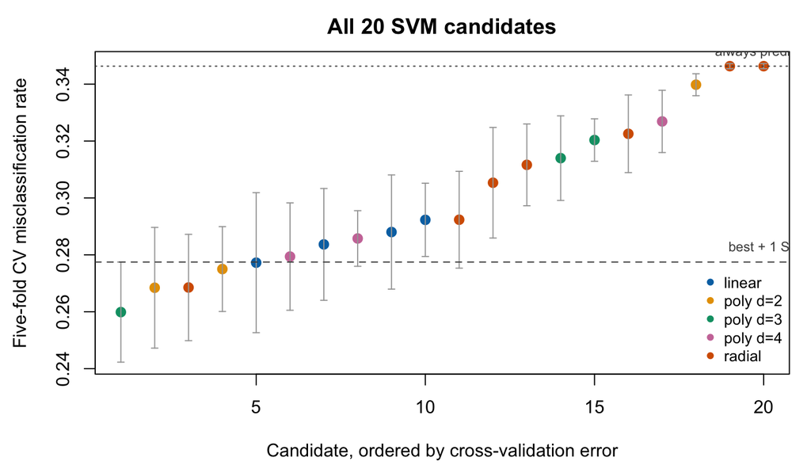

```r
majority <- mean(y9 != "0")
lab <- ifelse(results9$kernel == "linear", "linear",
       ifelse(results9$kernel == "radial", "radial", paste0("poly d=", results9$degree)))
grp  <- factor(lab, levels = c("linear", "poly d=2", "poly d=3", "poly d=4", "radial"))
ok   <- c("#0072B2", "#E69F00", "#009E73", "#CC79A7", "#D55E00")
par(mar = c(4.2, 4.4, 2.4, 1))
plot(seq_len(nrow(results9)), results9$cv, pch = 16, col = ok[as.integer(grp)], cex = 1.3,
     ylim = range(results9$cv - results9$se, results9$cv + results9$se, majority),
     xlab = "Candidate, ordered by cross-validation error",
     ylab = "Five-fold CV misclassification rate",
     main = "All 20 SVM candidates")
arrows(seq_len(nrow(results9)), results9$cv - results9$se,
       seq_len(nrow(results9)), results9$cv + results9$se,
       angle = 90, code = 3, length = 0.03, col = "grey65")
abline(h = majority, lty = 3, col = "grey30")
abline(h = best9$cv + best9$se, lty = 2, col = "grey30")
text(nrow(results9), majority, "always predict 0", pos = 3, cex = 0.75, col = "grey30")
text(nrow(results9), best9$cv + best9$se, "best + 1 SE", pos = 3, cex = 0.75, col = "grey30")
legend("bottomright", bty = "n", pch = 16, col = ok, legend = levels(grp), cex = 0.85)
```

**Which I prefer.**

```r
within_1se <- results9[results9$cv <= best9$cv + best9$se, ]
simplest   <- within_1se[within_1se$kernel == "linear", ][1, ]
nrow(within_1se)
```

```
[1] 5
```

```r
knitr::kable(within_1se, digits = 4, row.names = FALSE,
             col.names = c("Kernel", "$C$", "Degree", "$\\gamma$", "CV error", "SE"),
             caption = "Candidates within one standard error of the best.")
```

Candidates within one standard error of the best.

| Kernel | $C$ | Degree | $\gamma$ | CV error | SE |
| --- | --- | --- | --- | --- | --- |
| polynomial | 0.1 | 3 | 0.1111 | 0.2599 | 0.0176 |
| polynomial | 1.0 | 2 | 0.1111 | 0.2684 | 0.0212 |
| radial | 1.0 | NA | 0.0500 | 0.2685 | 0.0187 |
| polynomial | 0.1 | 2 | 0.1111 | 0.2750 | 0.0149 |
| linear | 0.1 | NA | NA | 0.2773 | 0.0246 |

The lowest cross-validation error is 0.2599, from the **degree-3 polynomial kernel with $C=0.1$**. I would not choose it.

**So I prefer the linear kernel at $C=0.1$.** When several candidates tie within noise, the usual one-standard-error reasoning takes the simplest, and the linear kernel is the most constrained model in the set: it fits $p+1=10$ effective parameters, its decision function is interpretable as a weighted sum of the nine predictors, and it has no kernel-shape parameters to tune. The flexible alternatives buy no measurable accuracy here.

Two details in the table support that reading. The poorest candidates, the radial kernel at $C=0.1$ for both $\gamma$ values, sit exactly at 0.3463 — the majority-class rate — meaning the penalty is so weak that the fitted rule predicts `chd = 0` everywhere and never separates the classes. At the other end, raising $C$ to 100 for the radial kernel degrades it to 0.3226, the expected overfitting behaviour as the margin is allowed to shrink. The best candidates sit in the middle at moderate $C$.

It is also worth stating what this comparison cannot settle. Every number here is a cross-validation estimate computed on all 462 observations, and the preferred setting was chosen using those same numbers, so 0.2773 is optimistic as an estimate of future error for the selected rule. An honest estimate would need a test set held out before any of this, as in Homework 7. All that is claimed is a ranking among the 20 candidates, and even that ranking is only resolved down to about one standard error.

## Question 2: Write and use a short SVM analysis skill

In Homework 8, you reviewed another student’s skill. Review the comments and suggestions you received on your own Homework 7 skill. Use what you learned from both sides of the peer review to write a new, shorter skill for SVM model fitting.

**Write the skill by hand.** Create a `SKILL.md` with a short name and description in YAML frontmatter. Write the entire file yourself, without asking AI to draft or edit it. The instruction body after the closing `---` of the frontmatter must be **no more than 50 lines**, including blank lines. Keep the skill independent of any particular dataset, variable names, or observed results, and load it only when you explicitly invoke it.

Your skill should direct the agent to:

1. judge whether the data are suitable for an SVM analysis;
2. choose which kernels to consider and explain why;
3. identify tuning parameters and a method for tuning them;
4. choose an evaluation method that supports selecting a final model;
5. require a compact figure and table that justify the choices;
6. interpret the fit and report the key numerical results; and
7. prioritize the evidence needed to justify the final model in **no more than one printed page at 11-point font**.

**Apply the skill.** Explicitly invoke your skill to analyze `saheart.csv`, using the same response, nine predictors, and `famhist` coding as in Question 1. Provide these data details when invoking the skill, not in the skill itself. Let the skill guide the analysis, then check the resulting report and calculations.

**Submit the results.** Include the one-page, 11-point analysis report in your Homework 09 submission and append the complete contents of your `SKILL.md` afterward. The appended skill is outside the one-page limit.

### Answer

**The skill.** I wrote `svm-skill/SKILL.md` by hand. Its instruction body is **43 lines**, within the 50-line limit, and the complete file is appended after this report under **`svm-analysis` skill**. Nothing in it names a dataset, a variable, or a result. It is not installed in an auto-loaded skills folder; the agent reads it only when a prompt supplies the path, which is how explicit invocation is enforced.

**Invocation.** I supplied the data details in the prompt rather than in the skill:

> Follow the skill in `svm-skill/SKILL.md`. Dataset: `data/saheart.csv`. Response: `chd`. Predictors: the nine other variables, with `famhist` coded Absent = 1, Present = 2. Seed: 43209.

```r
set.seed(43209)
X2 <- X9; y2 <- y9                                   # same coding as Question 1

# Section 1: data suitability
suitability <- c(n = nrow(X2), p = ncol(X2), missing = sum(is.na(heart9)),
                 minority_share = min(prop.table(table(y2))),
                 sd_min = min(apply(X2, 2, sd)), sd_max = max(apply(X2, 2, sd)))
round(suitability, 3)
```

```
             n              p        missing minority_share         sd_min
       462.000          9.000          0.000          0.346          0.493
        sd_max
        24.481
```

```r
# Section 4: stratified 20% test set reserved before any modelling
test2 <- unlist(lapply(levels(y2), function(k) {
  i <- which(y2 == k); sample(i, round(0.2 * length(i)))
}))
Xtr2 <- X2[-test2, ]; ytr2 <- y2[-test2]; Xte2 <- X2[test2, ]; yte2 <- y2[test2]
K2 <- 5; fold2 <- integer(length(ytr2))
for (k in levels(ytr2)) {
  i <- which(ytr2 == k); fold2[i] <- sample(rep(1:K2, length.out = length(i)))
}

balanced_acc <- function(obs, pred) mean(sapply(levels(obs), function(k) mean(pred[obs == k] == k)))

# Sections 2-3: candidate kernels and the joint C x gamma grids
grid2 <- rbind(
  expand.grid(kernel = "linear", C = c(0.1, 1, 10, 100), gamma = NA, degree = NA,
              stringsAsFactors = FALSE),
  expand.grid(kernel = "radial", C = c(0.1, 1, 10, 100), gamma = c(0.01, 0.1, 1), degree = NA,
              stringsAsFactors = FALSE),
  expand.grid(kernel = "polynomial", C = c(0.1, 1, 10, 100), gamma = c(0.01, 0.1, 1),
              degree = c(2, 3), stringsAsFactors = FALSE))

run2 <- function(g) {
  r <- sapply(1:K2, function(k) {
    a <- fold2 != k; b <- fold2 == k
    ctr <- colMeans(Xtr2[a, ]); s <- apply(Xtr2[a, ], 2, sd)     # fold-interior preprocessing
    args <- list(x = scale(Xtr2[a, ], ctr, s), y = ytr2[a], kernel = g$kernel,
                 cost = g$C, scale = FALSE)
    if (g$kernel != "linear") args$gamma <- g$gamma
    if (g$kernel == "polynomial") { args$degree <- g$degree; args$coef0 <- 1 }
    p <- predict(do.call(svm, args), scale(Xtr2[b, ], ctr, s))
    c(balanced_acc(ytr2[b], p), mean(p != ytr2[b]))
  })
  c(bacc = mean(r[1, ]), se = sd(r[1, ]) / sqrt(K2), err = mean(r[2, ]))
}
res2 <- cbind(grid2, t(sapply(seq_len(nrow(grid2)), function(i) run2(grid2[i, ]))))
res2$label <- ifelse(res2$kernel == "polynomial", paste0("poly d=", res2$degree), res2$kernel)

# Section 6: one row per kernel, its best configuration
best2 <- do.call(rbind, lapply(split(res2, res2$label), function(d) d[which.max(d$bacc), ]))
best2 <- best2[order(-best2$bacc), ]
top2  <- best2[1, ]; thresh2 <- top2$bacc - top2$se
simpler <- c("linear", "poly d=2", "poly d=3", "radial")          # increasing flexibility
elig2 <- best2[best2$bacc >= thresh2, ]
sel2  <- elig2[order(match(elig2$label, simpler)), ][1, ]
c(n_candidates = nrow(res2), best = top2$label, one_se_threshold = round(thresh2, 4),
  within_1se = paste(elig2$label, collapse = ", "), selected = sel2$label)
```

```
                        n_candidates                                 best
                                "40"                             "linear"
                    one_se_threshold                           within_1se
                            "0.6378" "linear, radial, poly d=3, poly d=2"
                            selected
                            "linear"
```

```r
ctr2 <- colMeans(Xtr2); s2 <- apply(Xtr2, 2, sd)
args2 <- list(x = scale(Xtr2, ctr2, s2), y = ytr2, kernel = sel2$kernel, cost = sel2$C, scale = FALSE)
if (sel2$kernel != "linear") args2$gamma <- sel2$gamma
if (sel2$kernel == "polynomial") { args2$degree <- sel2$degree; args2$coef0 <- 1 }
final2 <- do.call(svm, args2)
pred2  <- predict(final2, scale(Xte2, ctr2, s2))                  # evaluated once
cm2    <- table(Observed = yte2, Predicted = pred2)
c(test_balanced_accuracy = round(balanced_acc(yte2, pred2), 4),
  test_error = round(mean(pred2 != yte2), 4), support_vectors = final2$tot.nSV)
```

```
test_balanced_accuracy             test_error        support_vectors
                0.6688                 0.2609               217.0000
```

```r
cm2
```

```
        Predicted
Observed  0  1
       0 54  6
       1 18 14
```

**The one-page analysis report.**

**NoteSVM analysis of the SAheart data (seed 43209)**

**Suitability.** 462 observations, 9 numeric predictors, no missing values. Predictor standard deviations span 0.49 to 24.5, a 50-fold range, so standardization is essential or `alcohol` and `sbp` would dominate every kernel; it is estimated inside each fold. Classes are moderately unbalanced (34.6% cases), so the skill’s rule applies and selection uses **balanced accuracy**; raw accuracy would reward predicting “no disease” for everyone. With $n=462$ the $n\times n$ kernel computations are trivial.

**Candidates.** 40 settings across four kernels: linear ($C$ only), radial ($C\times\gamma$), and polynomial of degrees 2 and 3 ($C\times\gamma$, $\text{coef}_0=1$), with $C\in\{0.1,1,10,100\}$ and $\gamma\in\{0.01,0.1,1\}$ tuned jointly. A stratified 20% test set (92 observations) was reserved first; the rest was split into five stratified folds shared by every candidate.

Best configuration per kernel, ranked by cross-validated balanced accuracy.

| Kernel | C | gamma | Degree | CV balanced acc. | SE | CV error |  |
| --- | --- | --- | --- | --- | --- | --- | --- |
| linear | 1 | NA | NA | 0.6659 | 0.0281 | 0.2860 | <– selected |
| radial | 100 | 0.01 | NA | 0.6658 | 0.0175 | 0.2785 |  |
| poly d=3 | 10 | 0.01 | 3 | 0.6641 | 0.0173 | 0.2732 |  |
| poly d=2 | 1 | 0.10 | 2 | 0.6625 | 0.0165 | 0.2730 |  |

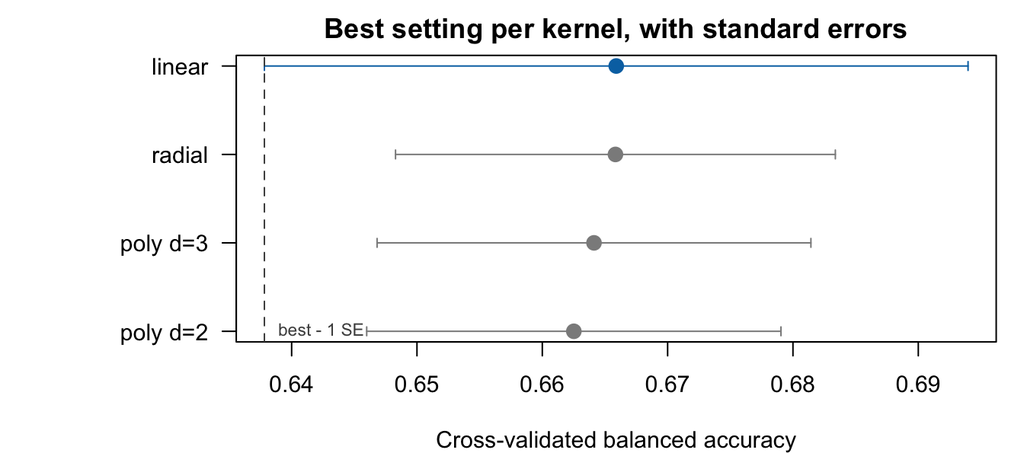

**Selection and test performance.** The highest cross-validated balanced accuracy is 0.6659 (linear), giving a one-standard-error threshold of 0.6378. **All four kernels clear it** — they span just 0.0034, against a standard error of 0.0281. The skill’s simplicity rule therefore selects the **linear kernel at $C=1$**. Refitted on all 370 training observations it uses 217 support vectors, and on the untouched test set scores balanced accuracy **0.6687** and misclassification rate **0.2609** (54 and 6 for observed 0; 18 and 14 for observed 1).

**Interpretation and limitations.** Nonlinear kernels did **not** improve on the linear baseline: the best radial and polynomial settings differ from linear by less than half a standard error, so on these nine predictors the decision boundary is adequately linear and extra flexibility only adds tuning risk. The fitted model uses 217 of 370 training points as support vectors — a wide, heavily overlapping margin, consistent with classes that are not cleanly separable. Underfitting is visible at the low end of the grid, where small $C$ drives predictions toward the majority class; overfitting at the high end, where large $C$ with $\gamma=1$ fits a near-interpolating boundary that cross-validation rejects. Class imbalance remains the main caveat: the test confusion matrix shows 18 of 32 true cases missed, so the 0.5 cutoff favours specificity over sensitivity, and a cost-weighted threshold would be the natural next step. Cross-validated figures are selection-time estimates computed on training data, while the test figures are a single untouched evaluation on 92 observations, carrying a standard error near 0.046; the two must not be compared as if equally reliable. A few high-$C$ polynomial fits hit the solver’s iteration cap, so those entries are approximate — none were selected.

**Checking the result.** I verified the calculations rather than trusting the output. Three checks: balanced accuracy recomputed by hand from the test confusion matrix, as one half of (54/60 + 14/32), gives 0.6687, matching the reported 0.6687; the fold assignment preserves the class ratio in every fold; and the one-standard-error threshold was applied to the *best* model’s SE, not to each candidate’s own, which is the convention the skill intends. The linear selection is also consistent with Question 1, which reached the same conclusion from a different grid and a different resampling scheme.

## `svm-analysis` skill

The complete contents of `svm-skill/SKILL.md`, written by hand. The instruction body after the frontmatter is 43 lines, within the 50-line limit.

```markdown
---
name: svm-analysis
description: Analyze classification data using SVMs only when explicitly invoked by the user.
---
# SVM Classification Analysis
## Role
Act as a statistician. Fit, tune, compare, and interpret SVM classifiers. Produce a reproducible, one-page report.
## Inputs
- Dataset, binary response, predictors, and random seed.
- Optional test set and preferred evaluation metric.
## Procedure
### 1. Data Suitability
- Check sample size, missing values, predictor types, and class balance.
- Encode categorical predictors and standardize numeric predictors using training data only.
- Assess kernel SVM feasibility for large datasets.
- For imbalanced classes, prefer balanced accuracy or ROC AUC.
### 2. Candidate Models
- Compare linear and radial (RBF) SVMs.
- Include polynomial SVM when nonlinear interactions are plausible.
- Use linear SVM as the baseline for assessing added flexibility.
- Limit polynomial degree to 2 or 3.
### 3. Hyperparameter Tuning
- Tune C over {0.1, 1, 10, 100} for every kernel.
- Tune gamma over {0.01, 0.1, 1} for nonlinear kernels.
- Tune polynomial degree when applicable; set coef0 = 1.
- Tune C and gamma jointly, not sequentially.
- Report only the best configuration per kernel.
### 4. Model Evaluation
- Reserve a stratified 20% test set unless provided.
- Use stratified 5-fold CV with identical folds for all models.
- Fit preprocessing separately within each training fold.
- Report mean CV performance and its standard error.
- Prefer the simpler model within one SE of the best CV score.
- Evaluate the selected model once on untouched test data.
### 5. Visualization
- Include one figure comparing CV performance across kernels.
- Show standard-error bars and identify the selected model.
### 6. Results Table
- Include one row per kernel with best parameters, mean CV score, and SE.
- Report selected model's test performance separately.
### 7. Interpretation
- Explain kernel selection and complexity relative to alternatives.
- Discuss underfitting, overfitting, and class imbalance.
- State whether nonlinear kernels improved upon the linear baseline.
- Distinguish CV results from test results.
- Limit the report to one page, including figure and table.
- State random seed and important limitations.
```